# Case Study 1

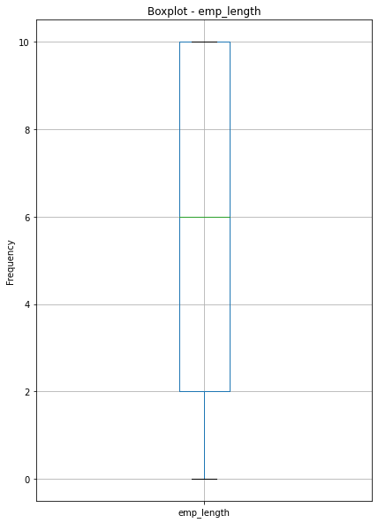

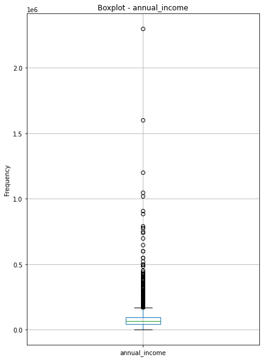

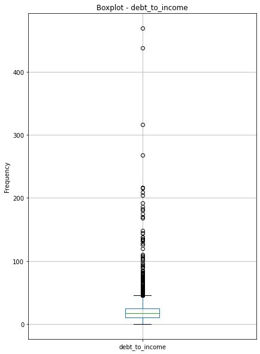

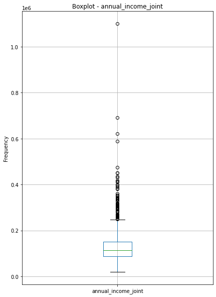

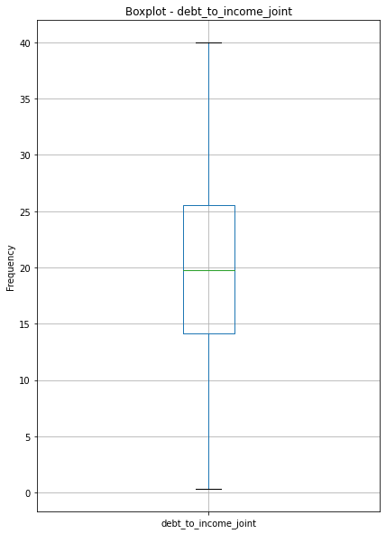

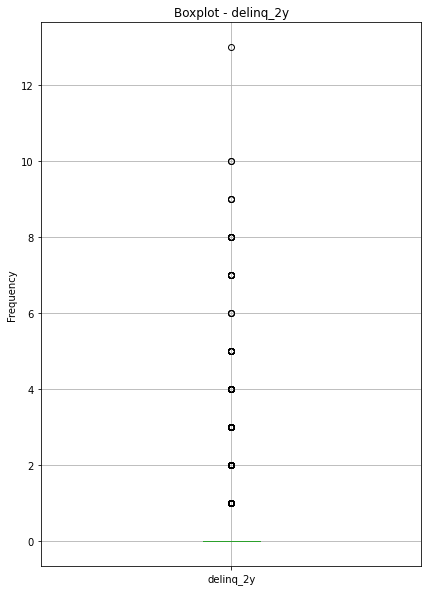

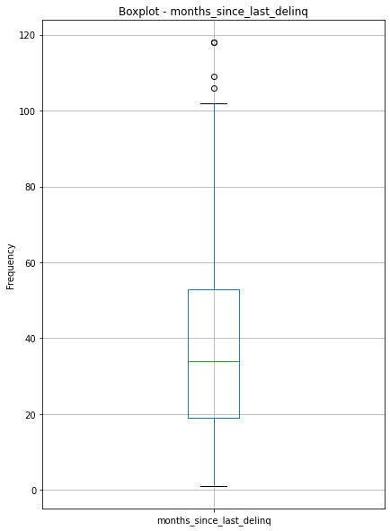

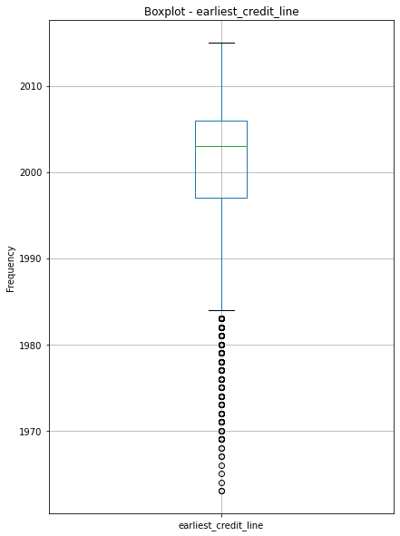

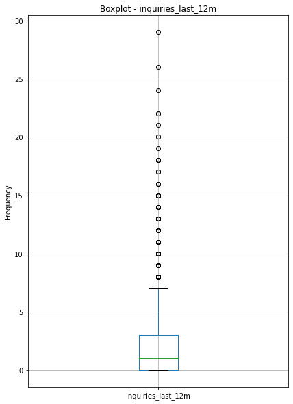

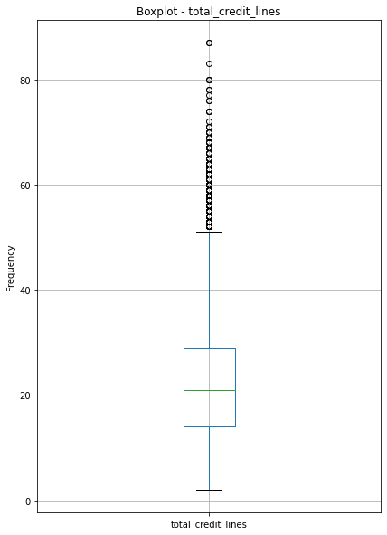

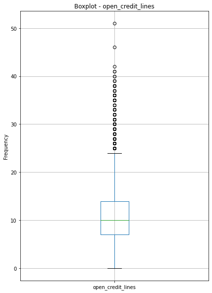

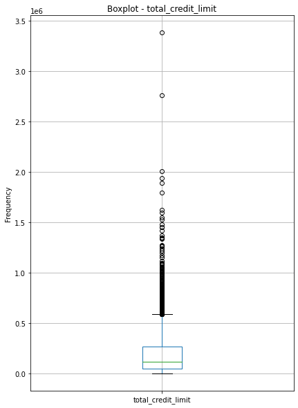

[30 more figures not shown]

```python
for column in loan_df.loc[:, ~loan_df.columns.isin(['emp_title', 'state', 'homeownership','verified_income',
                                                         'verification_income_joint','loan_purpose','application_type',
                                                         'grade', 'sub_grade', 'issue_month', 'loan_status',
                                                         'initial_listing_status','disbursement_method'])]:
    fig = plt.figure(figsize=(15, 10))
    ax1 = fig.add_subplot(121)
    ax1.set_ylabel('Frequency')
    ax1.set_title("Boxplot - {}".format(column))
    loan_df.boxplot(column=column)
```

There are a lot of outliers for many attributes as we can see in the boxplots

# Data Preprocessing

#### Step 1: Encoding

I encode the data using the label encoder, which is hierarchal encoder. I have used this encoder because it does not increase the dimensionality of the data.

```python
loan_df_encoded = loan_df
```

```python
le = LabelEncoder()
for column in loan_df[['emp_title', 'state', 'homeownership','verified_income',
                                                         'verification_income_joint','loan_purpose','application_type',
                                                         'grade', 'sub_grade', 'issue_month', 'loan_status',
                                                         'initial_listing_status','disbursement_method']]:
    loan_df_encoded[column] = le.fit_transform(loan_df[column])
```

```python
loan_df_encoded.head()
```

|  | emp_title | emp_length | state | homeownership | annual_income | verified_income | debt_to_income | annual_income_joint | verification_income_joint | debt_to_income_joint | delinq_2y | months_since_last_delinq | earliest_credit_line | inquiries_last_12m | total_credit_lines | open_credit_lines | total_credit_limit | total_credit_utilized | num_collections_last_12m | num_historical_failed_to_pay | months_since_90d_late | current_accounts_delinq | total_collection_amount_ever | current_installment_accounts | accounts_opened_24m | months_since_last_credit_inquiry | num_satisfactory_accounts | num_accounts_120d_past_due | num_accounts_30d_past_due | … |
| --- | --- | --- | --- | --- | --- | --- | --- | --- | --- | --- | --- | --- | --- | --- | --- | --- | --- | --- | --- | --- | --- | --- | --- | --- | --- | --- | --- | --- | --- | --- |
| 0 | 1777 | 3.0 | 30 | 0 | 90000.0 | 2 | 18.01 | NaN | 3 | NaN | 0 | 38.0 | 2001 | 6 | 28 | 10 | 70795 | 38767 | 0 | 0 | 38.0 | 0 | 1250 | 2 | 5 | 5.0 | 10 | 0.0 | 0 | … |
| 1 | 4675 | 10.0 | 11 | 2 | 40000.0 | 0 | 5.04 | NaN | 3 | NaN | 0 | NaN | 1996 | 1 | 30 | 14 | 28800 | 4321 | 0 | 1 | NaN | 0 | 0 | 0 | 11 | 8.0 | 14 | 0.0 | 0 | … |
| 2 | 207 | 3.0 | 47 | 2 | 40000.0 | 1 | 21.15 | NaN | 3 | NaN | 0 | 28.0 | 2006 | 4 | 31 | 10 | 24193 | 16000 | 0 | 0 | 28.0 | 0 | 432 | 1 | 13 | 7.0 | 10 | 0.0 | 0 | … |
| 3 | 1035 | 1.0 | 37 | 2 | 30000.0 | 0 | 10.16 | NaN | 3 | NaN | 0 | NaN | 2007 | 0 | 4 | 4 | 25400 | 4997 | 0 | 1 | NaN | 0 | 0 | 1 | 1 | 15.0 | 4 | 0.0 | 0 | … |
| 4 | 3710 | 10.0 | 4 | 2 | 35000.0 | 2 | 57.96 | 57000.0 | 2 | 37.66 | 0 | NaN | 2008 | 7 | 22 | 16 | 69839 | 52722 | 0 | 0 | NaN | 0 | 0 | 1 | 6 | 4.0 | 16 | 0.0 | 0 | … |

#### Dealing with columns with missing values

```python
loan_df_encoded = loan_df_encoded.drop(['annual_income_joint','verification_income_joint','debt_to_income_joint','months_since_90d_late'],axis=1)
```

#### Dropped the above columns as more than 50% of the data was missing

```python
loan_df_encoded.shape
```

```
(10000, 51)
```

#### knn imputation to fill the missing data

I used knn imputation here which applies the knn algorithm on the column and predicts the missing values. I used this method of prediction because using other imputation might have skewed the data. KNN approximates the values by the points that are closest to them.

```python
# import the KNNimputer class
from sklearn.impute import KNNImputer
# create an object for KNNImputer
imputer = KNNImputer(n_neighbors=2)
```

```python
imputer.fit(loan_df_encoded)
loan_df_encoded[:] = imputer.transform(loan_df_encoded)
```

```python
loan_df_encoded.isnull().sum()
```

```
emp_title                           0
emp_length                          0
state                               0
homeownership                       0
annual_income                       0
verified_income                     0
debt_to_income                      0
delinq_2y                           0
months_since_last_delinq            0
earliest_credit_line                0
inquiries_last_12m                  0
total_credit_lines                  0
open_credit_lines                   0
total_credit_limit                  0
total_credit_utilized               0
num_collections_last_12m            0
num_historical_failed_to_pay        0
current_accounts_delinq             0
total_collection_amount_ever        0
current_installment_accounts        0
accounts_opened_24m                 0
months_since_last_credit_inquiry    0
num_satisfactory_accounts           0
num_accounts_120d_past_due          0
num_accounts_30d_past_due           0
num_active_debit_accounts           0
total_debit_limit                   0
num_total_cc_accounts               0
num_open_cc_accounts                0
num_cc_carrying_balance             0
num_mort_accounts                   0
account_never_delinq_percent        0
tax_liens                           0
public_record_bankrupt              0
loan_purpose                        0
application_type                    0
loan_amount                         0
term                                0
interest_rate                       0
installment                         0
grade                               0
sub_grade                           0
issue_month                         0
loan_status                         0
initial_listing_status              0
disbursement_method                 0
balance                             0
paid_total                          0
paid_principal                      0
paid_interest                       0
paid_late_fees                      0
dtype: int64
```

```python
loan_df_encoded.shape
```

```
(10000, 51)
```

#### Scaling the data with a robust scaler

The data has many outliers so I chose the robust scaler since it uses the Interquartile range to normalize the data. Data normalization was needed here to give all the attributes the same influence for prediction

```python
scaler = RobustScaler()

x = loan_df_encoded.loc[:, ~loan_df_encoded.columns.isin(['emp_title', 'state', 'homeownership','verified_income',
                                                          'loan_purpose','application_type',
                                                          'grade', 'sub_grade', 'issue_month', 'loan_status',
                                                          'initial_listing_status','disbursement_method',
                                                               'emp_length', 'issue_month','delinq_2y','current_accounts_delinq',
                                                               'num_accounts_120d_past_due','interest_rate'])]
```

```python
x.head()
```

|  | annual_income | debt_to_income | months_since_last_delinq | earliest_credit_line | inquiries_last_12m | total_credit_lines | open_credit_lines | total_credit_limit | total_credit_utilized | num_collections_last_12m | num_historical_failed_to_pay | total_collection_amount_ever | current_installment_accounts | accounts_opened_24m | months_since_last_credit_inquiry | num_satisfactory_accounts | num_accounts_30d_past_due | num_active_debit_accounts | total_debit_limit | num_total_cc_accounts | num_open_cc_accounts | num_cc_carrying_balance | num_mort_accounts | account_never_delinq_percent | tax_liens | public_record_bankrupt | loan_amount | term | installment | … |
| --- | --- | --- | --- | --- | --- | --- | --- | --- | --- | --- | --- | --- | --- | --- | --- | --- | --- | --- | --- | --- | --- | --- | --- | --- | --- | --- | --- | --- | --- | --- |
| 0 | 90000.0 | 18.01 | 38.0 | 2001.0 | 6.0 | 28.0 | 10.0 | 70795.0 | 38767.0 | 0.0 | 0.0 | 1250.0 | 2.0 | 5.0 | 5.0 | 10.0 | 0.0 | 2.0 | 11100.0 | 14.0 | 8.0 | 6.0 | 1.0 | 92.9 | 0.0 | 0.0 | 28000.0 | 60.0 | 652.53 | … |
| 1 | 40000.0 | 5.04 | 26.0 | 1996.0 | 1.0 | 30.0 | 14.0 | 28800.0 | 4321.0 | 0.0 | 1.0 | 0.0 | 0.0 | 11.0 | 8.0 | 14.0 | 0.0 | 3.0 | 16500.0 | 24.0 | 14.0 | 4.0 | 0.0 | 100.0 | 0.0 | 1.0 | 5000.0 | 36.0 | 167.54 | … |
| 2 | 40000.0 | 21.15 | 28.0 | 2006.0 | 4.0 | 31.0 | 10.0 | 24193.0 | 16000.0 | 0.0 | 0.0 | 432.0 | 1.0 | 13.0 | 7.0 | 10.0 | 0.0 | 3.0 | 4300.0 | 14.0 | 8.0 | 6.0 | 0.0 | 93.5 | 0.0 | 0.0 | 2000.0 | 36.0 | 71.40 | … |
| 3 | 30000.0 | 10.16 | 47.5 | 2007.0 | 0.0 | 4.0 | 4.0 | 25400.0 | 4997.0 | 0.0 | 1.0 | 0.0 | 1.0 | 1.0 | 15.0 | 4.0 | 0.0 | 2.0 | 19400.0 | 3.0 | 3.0 | 2.0 | 0.0 | 100.0 | 1.0 | 0.0 | 21600.0 | 36.0 | 664.19 | … |
| 4 | 35000.0 | 57.96 | 40.0 | 2008.0 | 7.0 | 22.0 | 16.0 | 69839.0 | 52722.0 | 0.0 | 0.0 | 0.0 | 1.0 | 6.0 | 4.0 | 16.0 | 0.0 | 10.0 | 32700.0 | 20.0 | 15.0 | 13.0 | 0.0 | 100.0 | 0.0 | 0.0 | 23000.0 | 36.0 | 786.87 | … |

```python
x.shape
```

```
(10000, 34)
```

```python
x[x.columns] = scaler.fit_transform(x[x.columns])
```

```python
x_scaled = x
```

```python
x.shape
```

```
(10000, 34)
```

```python
x_scaled.head()
```

|  | annual_income | debt_to_income | months_since_last_delinq | earliest_credit_line | inquiries_last_12m | total_credit_lines | open_credit_lines | total_credit_limit | total_credit_utilized | num_collections_last_12m | num_historical_failed_to_pay | total_collection_amount_ever | current_installment_accounts | accounts_opened_24m | months_since_last_credit_inquiry | num_satisfactory_accounts | num_accounts_30d_past_due | num_active_debit_accounts | total_debit_limit | num_total_cc_accounts | num_open_cc_accounts | num_cc_carrying_balance | num_mort_accounts | account_never_delinq_percent | tax_liens | public_record_bankrupt | loan_amount | term | installment | … |
| --- | --- | --- | --- | --- | --- | --- | --- | --- | --- | --- | --- | --- | --- | --- | --- | --- | --- | --- | --- | --- | --- | --- | --- | --- | --- | --- | --- | --- | --- | --- |
| 0 | 0.5 | 0.029280 | 0.075472 | -0.222222 | 1.666667 | 0.466667 | 0.000000 | -0.203152 | 0.039796 | 0.0 | 0.0 | 1250.0 | 0.0 | 0.25 | -0.125 | 0.000000 | 0.0 | -0.333333 | -0.321839 | 0.3 | 0.2 | 0.25 | 0.0 | -0.959459 | 0.0 | 0.0 | 0.84375 | 1.0 | 0.653827 | … |
| 1 | -0.5 | -0.896983 | -0.377358 | -0.777778 | 0.000000 | 0.600000 | 0.571429 | -0.397613 | -0.705216 | 0.0 | 1.0 | 0.0 | -1.0 | 1.75 | 0.250 | 0.571429 | 0.0 | 0.000000 | -0.114943 | 1.3 | 1.4 | -0.25 | -0.5 | 0.000000 | 0.0 | 1.0 | -0.59375 | 0.0 | -0.594056 | … |
| 2 | -0.5 | 0.253526 | -0.301887 | 0.333333 | 1.000000 | 0.666667 | 0.000000 | -0.418946 | -0.452618 | 0.0 | 0.0 | 432.0 | -0.5 | 2.25 | 0.125 | 0.000000 | 0.0 | 0.000000 | -0.582375 | 0.3 | 0.2 | 0.25 | -0.5 | -0.878378 | 0.0 | 0.0 | -0.78125 | 0.0 | -0.841425 | … |
| 3 | -0.7 | -0.531334 | 0.433962 | 0.444444 | -0.333333 | -1.133333 | -0.857143 | -0.413357 | -0.690595 | 0.0 | 1.0 | 0.0 | -0.5 | -0.75 | 1.125 | -0.857143 | 0.0 | -0.333333 | -0.003831 | -0.8 | -0.8 | -0.75 | -0.5 | 0.000000 | 1.0 | 0.0 | 0.44375 | 0.0 | 0.683829 | … |
| 4 | -0.6 | 2.882342 | 0.150943 | 0.555556 | 2.000000 | 0.066667 | 0.857143 | -0.207579 | 0.341621 | 0.0 | 0.0 | 0.0 | -0.5 | 0.50 | -0.250 | 0.857143 | 0.0 | 2.333333 | 0.505747 | 0.9 | 1.6 | 2.00 | -0.5 | 0.000000 | 0.0 | 0.0 | 0.53125 | 0.0 | 0.999485 | … |

```python
x_scaled.shape
```

```
(10000, 34)
```

```python
loan_df_categorical = loan_df_encoded[['emp_title', 'state', 'homeownership','verified_income',
                                                          'loan_purpose','application_type',
                                                          'grade', 'sub_grade', 'issue_month', 'loan_status',
                                                          'initial_listing_status','disbursement_method',
                                                               'emp_length', 'issue_month','delinq_2y','current_accounts_delinq',
                                                               'num_accounts_120d_past_due','interest_rate']]
```

```python
loan_df_scaled = pd.concat([loan_df_categorical,x_scaled],axis=1)
```

```python
loan_df_scaled.shape
```

```
(10000, 52)
```

```python
loan_df_scaled.head(10)
```

|  | emp_title | state | homeownership | verified_income | loan_purpose | application_type | grade | sub_grade | issue_month | loan_status | initial_listing_status | disbursement_method | emp_length | issue_month | delinq_2y | current_accounts_delinq | num_accounts_120d_past_due | interest_rate | annual_income | debt_to_income | months_since_last_delinq | earliest_credit_line | inquiries_last_12m | total_credit_lines | open_credit_lines | total_credit_limit | total_credit_utilized | num_collections_last_12m | num_historical_failed_to_pay | … |
| --- | --- | --- | --- | --- | --- | --- | --- | --- | --- | --- | --- | --- | --- | --- | --- | --- | --- | --- | --- | --- | --- | --- | --- | --- | --- | --- | --- | --- | --- | --- |
| 0 | 1777.0 | 30.0 | 0.0 | 2.0 | 7.0 | 0.0 | 2.0 | 12.0 | 2.0 | 1.0 | 1.0 | 0.0 | 3.0 | 2.0 | 0.0 | 0.0 | 0.0 | 14.07 | 0.50 | 0.029280 | 0.075472 | -0.222222 | 1.666667 | 0.466667 | 0.000000 | -0.203152 | 0.039796 | 0.0 | 0.0 | … |
| 1 | 4675.0 | 11.0 | 2.0 | 0.0 | 2.0 | 0.0 | 2.0 | 10.0 | 0.0 | 1.0 | 1.0 | 0.0 | 10.0 | 0.0 | 0.0 | 0.0 | 0.0 | 12.61 | -0.50 | -0.896983 | -0.377358 | -0.777778 | 0.000000 | 0.600000 | 0.571429 | -0.397613 | -0.705216 | 0.0 | 1.0 | … |
| 2 | 207.0 | 47.0 | 2.0 | 1.0 | 8.0 | 0.0 | 3.0 | 15.0 | 0.0 | 1.0 | 0.0 | 0.0 | 3.0 | 0.0 | 0.0 | 0.0 | 0.0 | 17.09 | -0.50 | 0.253526 | -0.301887 | 0.333333 | 1.000000 | 0.666667 | 0.000000 | -0.418946 | -0.452618 | 0.0 | 0.0 | … |
| 3 | 1035.0 | 37.0 | 2.0 | 0.0 | 2.0 | 0.0 | 0.0 | 2.0 | 1.0 | 1.0 | 1.0 | 0.0 | 1.0 | 1.0 | 0.0 | 0.0 | 0.0 | 6.72 | -0.70 | -0.531334 | 0.433962 | 0.444444 | -0.333333 | -1.133333 | -0.857143 | -0.413357 | -0.690595 | 0.0 | 1.0 | … |
| 4 | 3710.0 | 4.0 | 2.0 | 2.0 | 1.0 | 1.0 | 2.0 | 12.0 | 2.0 | 1.0 | 1.0 | 0.0 | 10.0 | 2.0 | 0.0 | 0.0 | 0.0 | 14.07 | -0.60 | 2.882342 | 0.150943 | 0.555556 | 2.000000 | 0.066667 | 0.857143 | -0.207579 | 0.341621 | 0.0 | 0.0 | … |
| 5 | 4741.0 | 16.0 | 1.0 | 0.0 | 8.0 | 0.0 | 0.0 | 2.0 | 1.0 | 1.0 | 1.0 | 0.0 | 3.5 | 1.0 | 1.0 | 0.0 | 0.0 | 6.72 | -0.62 | -0.795572 | -1.245283 | -1.444444 | 1.666667 | 0.733333 | 0.285714 | -0.336026 | -0.714365 | 0.0 | 0.0 | … |
| 6 | 1908.0 | 21.0 | 0.0 | 1.0 | 1.0 | 1.0 | 2.0 | 11.0 | 1.0 | 1.0 | 1.0 | 0.0 | 10.0 | 1.0 | 0.0 | 0.0 | 0.0 | 13.59 | -0.60 | 0.432780 | 0.830189 | 0.111111 | 0.000000 | -0.600000 | 0.000000 | 0.820467 | -0.389549 | 0.0 | 0.0 | … |
| 7 | 3049.0 | 3.0 | 0.0 | 1.0 | 2.0 | 0.0 | 1.0 | 9.0 | 1.0 | 1.0 | 1.0 | 0.0 | 10.0 | 1.0 | 1.0 | 0.0 | 0.0 | 11.99 | 0.90 | -0.100696 | -0.641509 | 0.222222 | 0.000000 | 0.600000 | 0.714286 | 1.054237 | 0.516443 | 0.0 | 0.0 | … |
| 8 | 2906.0 | 32.0 | 0.0 | 1.0 | 3.0 | 0.0 | 2.0 | 11.0 | 0.0 | 1.0 | 1.0 | 0.0 | 10.0 | 0.0 | 1.0 | 0.0 | 0.0 | 13.59 | 0.00 | 1.348331 | -0.679245 | -0.555556 | 0.666667 | 0.933333 | 1.571429 | 0.780357 | 0.705821 | 0.0 | 0.0 | … |
| 9 | 18.0 | 13.0 | 2.0 | 0.0 | 1.0 | 0.0 | 0.0 | 2.0 | 2.0 | 1.0 | 0.0 | 0.0 | 3.0 | 2.0 | 0.0 | 0.0 | 0.0 | 6.71 | -0.70 | 0.093555 | 0.358491 | -0.222222 | -0.333333 | -0.800000 | -0.571429 | -0.377637 | -0.414379 | 0.0 | 0.0 | … |

```python
print(loan_df_encoded.columns.values.tolist())
print(loan_df_scaled.columns.values.tolist())
```

```
['emp_title', 'emp_length', 'state', 'homeownership', 'annual_income', 'verified_income', 'debt_to_income', 'delinq_2y', 'months_since_last_delinq', 'earliest_credit_line', 'inquiries_last_12m', 'total_credit_lines', 'open_credit_lines', 'total_credit_limit', 'total_credit_utilized', 'num_collection…
['emp_title', 'state', 'homeownership', 'verified_income', 'loan_purpose', 'application_type', 'grade', 'sub_grade', 'issue_month', 'loan_status', 'initial_listing_status', 'disbursement_method', 'emp_length', 'issue_month', 'delinq_2y', 'current_accounts_delinq', 'num_accounts_120d_past_due', 'inte…
```

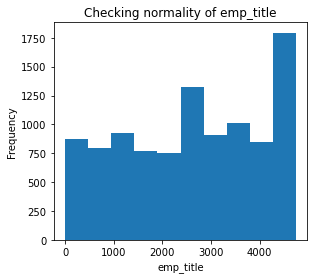

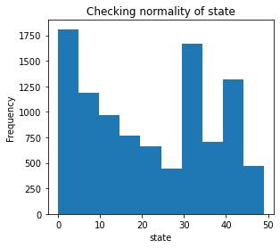

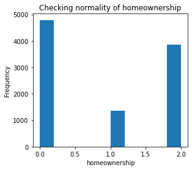

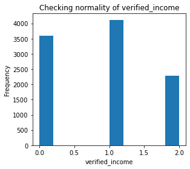

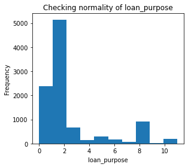

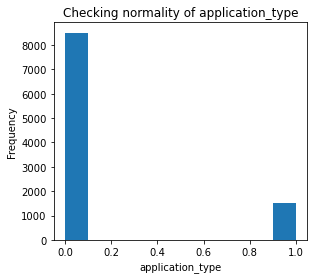

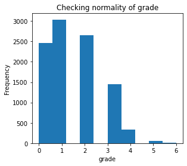

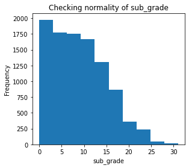

[figure not shown]

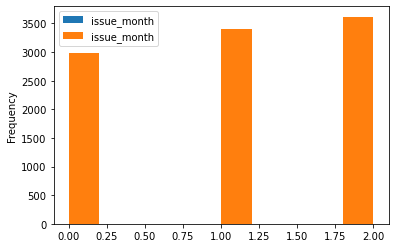

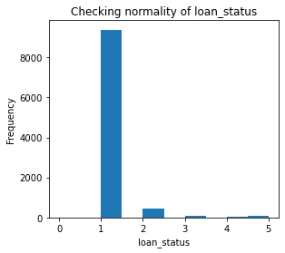

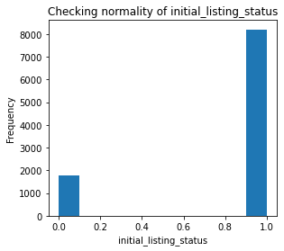

[42 more figures not shown]

```python
for column in loan_df_scaled:
    fig = plt.figure(figsize=(10,4))
    ax1 = fig.add_subplot(121)
    ax1.set_xlabel("{}".format(column))
    ax1.set_ylabel('Frequency')
    ax1.set_title("Checking normality of {}".format(column))
    loan_df_scaled[column].plot(kind="hist")
```

```python
loan_df_encoded.installment.unique()
```

```
array([ 652.53,  167.54,   71.4 , ...,  103.14, 1175.1 ,  418.52])
```

# Visualizations

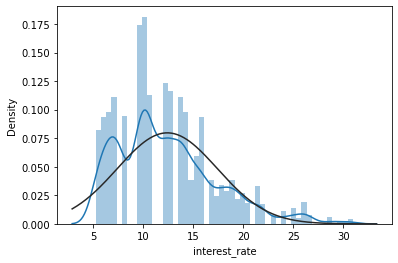

```python
from scipy.stats import norm
sns.distplot(loan_df_scaled['interest_rate'], fit=norm)
plt.show()
```

This visualization shows that there is a positive skew in the interest rate for the data

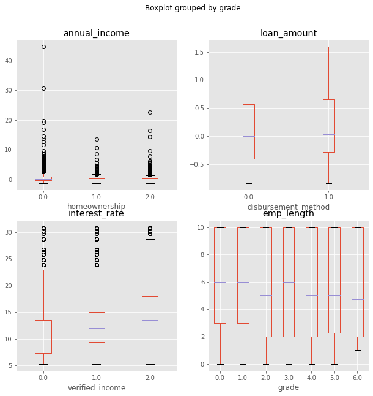

```python
fig, axes = plt.subplots(2,2)
fig = plt.figure(figsize=(10,6))
col_list = ['annual_income', 'loan_amount', 'interest_rate', 'emp_length']
by_dict = {0: 'homeownership', 1:"disbursement_method", 2:"verified_income", 3:"grade"}

for i,el in enumerate(col_list):
    a = loan_df_scaled.boxplot(el, by=by_dict[i], ax=axes.flatten()[i])

plt.tight_layout()
plt.show()
```

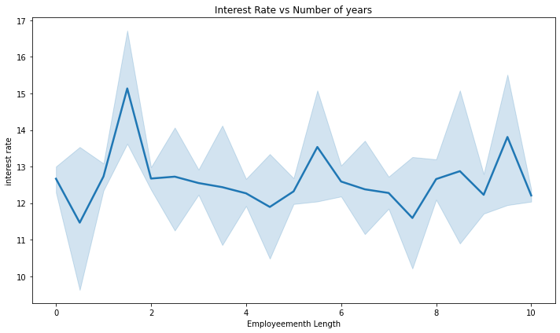

```python
plt.figure(figsize=(10,6), tight_layout=True)

ax = sns.lineplot(x=loan_df_scaled['emp_length'], y=loan_df_scaled['interest_rate'], palette='Set2', linewidth=2.5)
ax.set(title='Interest Rate vs Number of years', xlabel='Employeementh Length', ylabel='interest rate')
plt.show()
```

As seen, the intereste rate peaks for people with 1-2 years of experience. There is a slight increase at 5 years of employment too.

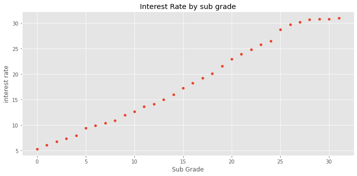

```python
info = loan_df.copy()
a = info.groupby('sub_grade').mean()
plt.figure(figsize=(10,5),tight_layout=True)
ax = sns.scatterplot(x=a.index, y=a['interest_rate'], palette='Set2')
ax.set(title='Interest Rate by sub grade', xlabel='Sub Grade', ylabel='interest rate')
plt.show()
```

Interest rate by the average of the sub_grade. As the subgrade increases from A-D, reases othe interest rate also increases on average

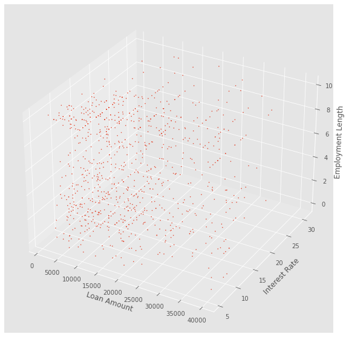

```python
from mpl_toolkits import mplot3d
info = loan_df[:1000]

fig = plt.figure()
ax = plt.axes(projection='3d')

xs = info['loan_amount']
zs = info['emp_length']
ys = info['interest_rate']
ax.scatter(xs, ys, zs, s=1, alpha=1)


ax.set_xlabel('Loan Amount')
ax.set_ylabel('Interest Rate')
ax.set_zlabel('Employment Length')
plt.show()
```

A spatial view of how interest rate is affected by length of employment and loan amount. It looks like loan amount affects the rate of interest more than the employment length

```python
loan_df.head()
```

[output not shown]

# Train-Test Split

```python
import statsmodels.api as sm
import statsmodels.formula.api as smf
import sklearn.linear_model as lm
from sklearn import datasets, linear_model, model_selection
import sklearn
from sklearn.model_selection import train_test_split
from sklearn.linear_model import LinearRegression, Lasso, Ridge
from sklearn.model_selection import cross_val_score
from sklearn.model_selection import RepeatedKFold
from statsmodels.stats.outliers_influence import variance_inflation_factor
from sklearn.metrics import mean_squared_error, r2_score
```

```python
#Partition the data
#Create training and test datasets
X = loan_df_scaled.loc[:, ~loan_df_scaled.columns.isin(['interest_rate'])]
Y = loan_df_scaled['interest_rate']

X_train, X_test, Y_train, Y_test = sklearn.model_selection.train_test_split(X, Y, test_size = 0.20, random_state = 5)
```

```python
X.shape
```

```
(10000, 51)
```

```python
Y.shape
```

```
(10000,)
```

```python
X_train.shape, X_test.shape
```

```
((8000, 51), (2000, 51))
```

```python
loan_df_scaled.head(10)
```

|  | emp_title | state | homeownership | verified_income | loan_purpose | application_type | grade | sub_grade | issue_month | loan_status | initial_listing_status | disbursement_method | emp_length | issue_month | delinq_2y | current_accounts_delinq | num_accounts_120d_past_due | interest_rate | annual_income | debt_to_income | months_since_last_delinq | earliest_credit_line | inquiries_last_12m | total_credit_lines | open_credit_lines | total_credit_limit | total_credit_utilized | num_collections_last_12m | num_historical_failed_to_pay | … |
| --- | --- | --- | --- | --- | --- | --- | --- | --- | --- | --- | --- | --- | --- | --- | --- | --- | --- | --- | --- | --- | --- | --- | --- | --- | --- | --- | --- | --- | --- | --- |
| 0 | 1777.0 | 30.0 | 0.0 | 2.0 | 7.0 | 0.0 | 2.0 | 12.0 | 2.0 | 1.0 | 1.0 | 0.0 | 3.0 | 2.0 | 0.0 | 0.0 | 0.0 | 14.07 | 0.50 | 0.029280 | 0.075472 | -0.222222 | 1.666667 | 0.466667 | 0.000000 | -0.203152 | 0.039796 | 0.0 | 0.0 | … |
| 1 | 4675.0 | 11.0 | 2.0 | 0.0 | 2.0 | 0.0 | 2.0 | 10.0 | 0.0 | 1.0 | 1.0 | 0.0 | 10.0 | 0.0 | 0.0 | 0.0 | 0.0 | 12.61 | -0.50 | -0.896983 | -0.377358 | -0.777778 | 0.000000 | 0.600000 | 0.571429 | -0.397613 | -0.705216 | 0.0 | 1.0 | … |
| 2 | 207.0 | 47.0 | 2.0 | 1.0 | 8.0 | 0.0 | 3.0 | 15.0 | 0.0 | 1.0 | 0.0 | 0.0 | 3.0 | 0.0 | 0.0 | 0.0 | 0.0 | 17.09 | -0.50 | 0.253526 | -0.301887 | 0.333333 | 1.000000 | 0.666667 | 0.000000 | -0.418946 | -0.452618 | 0.0 | 0.0 | … |
| 3 | 1035.0 | 37.0 | 2.0 | 0.0 | 2.0 | 0.0 | 0.0 | 2.0 | 1.0 | 1.0 | 1.0 | 0.0 | 1.0 | 1.0 | 0.0 | 0.0 | 0.0 | 6.72 | -0.70 | -0.531334 | 0.433962 | 0.444444 | -0.333333 | -1.133333 | -0.857143 | -0.413357 | -0.690595 | 0.0 | 1.0 | … |
| 4 | 3710.0 | 4.0 | 2.0 | 2.0 | 1.0 | 1.0 | 2.0 | 12.0 | 2.0 | 1.0 | 1.0 | 0.0 | 10.0 | 2.0 | 0.0 | 0.0 | 0.0 | 14.07 | -0.60 | 2.882342 | 0.150943 | 0.555556 | 2.000000 | 0.066667 | 0.857143 | -0.207579 | 0.341621 | 0.0 | 0.0 | … |
| 5 | 4741.0 | 16.0 | 1.0 | 0.0 | 8.0 | 0.0 | 0.0 | 2.0 | 1.0 | 1.0 | 1.0 | 0.0 | 3.5 | 1.0 | 1.0 | 0.0 | 0.0 | 6.72 | -0.62 | -0.795572 | -1.245283 | -1.444444 | 1.666667 | 0.733333 | 0.285714 | -0.336026 | -0.714365 | 0.0 | 0.0 | … |
| 6 | 1908.0 | 21.0 | 0.0 | 1.0 | 1.0 | 1.0 | 2.0 | 11.0 | 1.0 | 1.0 | 1.0 | 0.0 | 10.0 | 1.0 | 0.0 | 0.0 | 0.0 | 13.59 | -0.60 | 0.432780 | 0.830189 | 0.111111 | 0.000000 | -0.600000 | 0.000000 | 0.820467 | -0.389549 | 0.0 | 0.0 | … |
| 7 | 3049.0 | 3.0 | 0.0 | 1.0 | 2.0 | 0.0 | 1.0 | 9.0 | 1.0 | 1.0 | 1.0 | 0.0 | 10.0 | 1.0 | 1.0 | 0.0 | 0.0 | 11.99 | 0.90 | -0.100696 | -0.641509 | 0.222222 | 0.000000 | 0.600000 | 0.714286 | 1.054237 | 0.516443 | 0.0 | 0.0 | … |
| 8 | 2906.0 | 32.0 | 0.0 | 1.0 | 3.0 | 0.0 | 2.0 | 11.0 | 0.0 | 1.0 | 1.0 | 0.0 | 10.0 | 0.0 | 1.0 | 0.0 | 0.0 | 13.59 | 0.00 | 1.348331 | -0.679245 | -0.555556 | 0.666667 | 0.933333 | 1.571429 | 0.780357 | 0.705821 | 0.0 | 0.0 | … |
| 9 | 18.0 | 13.0 | 2.0 | 0.0 | 1.0 | 0.0 | 0.0 | 2.0 | 2.0 | 1.0 | 0.0 | 0.0 | 3.0 | 2.0 | 0.0 | 0.0 | 0.0 | 6.71 | -0.70 | 0.093555 | 0.358491 | -0.222222 | -0.333333 | -0.800000 | -0.571429 | -0.377637 | -0.414379 | 0.0 | 0.0 | … |

# Multiple Linear Regression

```python
#Model statistics
#Must add constant for y-intercept
model = sm.OLS(Y_train, sm.add_constant(X_train)).fit()
Y_pred = model.predict(sm.add_constant(X_test))
print_model = model.summary()
print(print_model)
```

```
                            OLS Regression Results
==============================================================================
Dep. Variable:          interest_rate   R-squared:                       0.988
Model:                            OLS   Adj. R-squared:                  0.987
Method:                 Least Squares   F-statistic:                 1.339e+04
Date:                Tue, 12 Apr 2022   Prob (F-statistic):               0.00
Time:                        14:41:36   Log-Likelihood:                -6659.5
No. Observations:                8000   AIC:                         1.341e+04
Df Residuals:                    7952   BIC:                         1.375e+04
Df Model:                          47
Covariance Type:            nonrobust
====================================================================================================
                                       coef    std err          t      P>|t|      [0.025      0.975]
----------------------------------------------------------------------------------------------------
const                              -12.5538   1384.968     -0.009      0.993   -2727.454    2702.347
emp_title                         5.379e-07   4.35e-06      0.124      0.902   -7.99e-06    9.07e-06
state                                0.0002      0.000      0.423      0.672      -0.001       0.001
homeownership                       -0.0024      0.009     -0.272      0.786      -0.020       0.015
verified_income                     -0.0015      0.009     -0.173      0.863      -0.019       0.016
loan_purpose                         0.0039      0.003      1.351      0.177      -0.002       0.009
application_type                     0.0523      0.020      2.670      0.008       0.014       0.091
grade                                0.4148      0.023     18.384      0.000       0.371       0.459
sub_grade                            0.7496      0.005    159.897      0.000       0.740       0.759
issue_month                          0.0200      0.004      4.929      0.000       0.012       0.028
loan_status                          0.0548      0.015      3.553      0.000       0.025       0.085
initial_listing_status               0.0368      0.017      2.129      0.033       0.003       0.071
disbursement_method                  0.1288      0.025      5.155      0.000       0.080       0.178
emp_length                           0.0033      0.002      1.841      0.066      -0.000       0.007
issue_month                          0.0200      0.004      4.929      0.000       0.012       0.028
delinq_2y                           -0.0293      0.012     -2.507      0.012      -0.052      -0.006
current_accounts_delinq             -0.2324      0.280     -0.829      0.407      -0.782       0.317
num_accounts_120d_past_due        1.024e-12   8.29e-11      0.012      0.990   -1.61e-10    1.63e-10
annual_income                        0.0009      0.006      0.135      0.893      -0.012       0.014
debt_to_income                      -0.0173      0.007     -2.497      0.013      -0.031      -0.004
months_since_last_delinq            -0.0095      0.010     -0.937      0.349      -0.029       0.010
earliest_credit_line                -0.0187      0.008     -2.229      0.026      -0.035      -0.002
inquiries_last_12m                  -0.0215      0.010     -2.194      0.028      -0.041      -0.002
total_credit_lines                   0.0299      0.019      1.567      0.117      -0.008       0.067
open_credit_lines                    0.0411      0.241      0.171      0.864      -0.431       0.513
total_credit_limit                   0.0239      0.013      1.845      0.065      -0.001       0.049
```

[output cut: 22 more lines]

```
paid_total                        -218.8138   1.77e+04     -0.012      0.990   -3.49e+04    3.44e+04
paid_principal                     143.5861   1.16e+04      0.012      0.990   -2.26e+04    2.29e+04
paid_interest                       78.4356   6325.589      0.012      0.990   -1.23e+04    1.25e+04
paid_late_fees                       0.1259     10.479      0.012      0.990     -20.415      20.667
==============================================================================
Omnibus:                     5659.073   Durbin-Watson:                   1.996
Prob(Omnibus):                  0.000   Jarque-Bera (JB):          1684632.248
Skew:                          -2.288   Prob(JB):                         0.00
Kurtosis:                      73.943   Cond. No.                     1.14e+16
==============================================================================

Notes:
[1] Standard Errors assume that the covariance matrix of the errors is correctly specified.
[2] The smallest eigenvalue is 5.58e-22. This might indicate that there are
strong multicollinearity problems or that the design matrix is singular.
```

A R2 score of 0.988 means that the values fit the data very well and the predictor variable (interest rate) is explained well by the data

Something additional we could do is calculate the Variance Inflation score to check for multicollinearity and eliminate the highly collinear columns

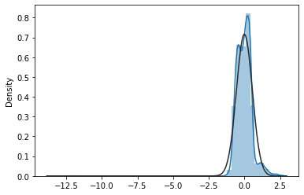

```python
from scipy import stats
sns.distplot(model.resid, fit=stats.norm);
```

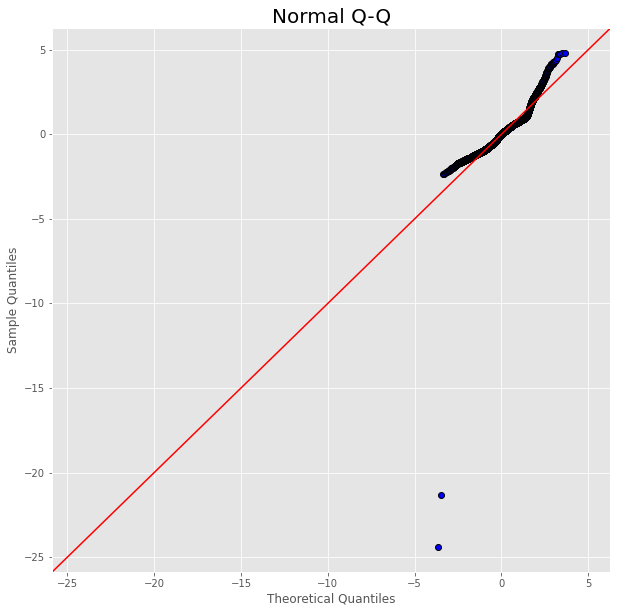

```python
#Normal Q-Q Plot

plt.rc('figure', figsize=(10,10))
plt.style.use('ggplot')

probplot = sm.ProbPlot(model.get_influence().resid_studentized_internal, fit=True)
fig = probplot.qqplot(line='45', marker='o', color='black')
plt.title('Normal Q-Q', fontsize=20)
plt.show()
```

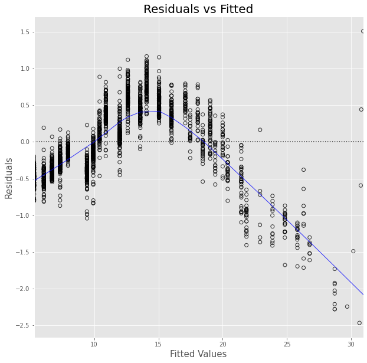

```python
#Residuals vs Fitted

# Plotting the residuals of y and pred_y
sns.residplot(Y_test,Y_pred, lowess=True,
                          scatter_kws={'facecolors':'none', 'edgecolors':'black'},
                          line_kws={'color': 'blue', 'lw': 1, 'alpha': 0.8})
plt.title('Residuals vs Fitted', fontsize=20)
plt.xlabel('Fitted Values', fontsize=15)
plt.ylabel('Residuals', fontsize=15)
```

shows that the residuals are mostly negative when the fitted value is small, positive when the fitted value is in the middle and negative when the fitted value is large. That is, the spread is approximately constant, but the conditional mean is not - the fitted line doesn't describe how 𝑦 behaves as 𝑥 changes, since the relationship is curved

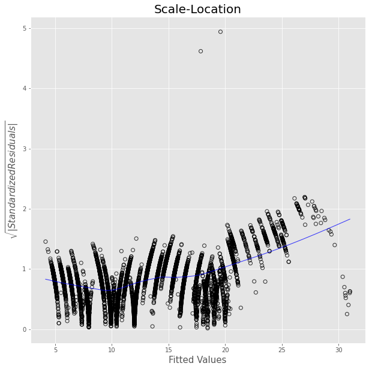

```python
#Scale-Location Plot

sns.regplot(model.fittedvalues,
           np.sqrt(np.abs(model.get_influence().resid_studentized_internal)),
            scatter=True,
            ci=False,
            lowess=True,
            line_kws={'color': 'blue', 'lw': 1, 'alpha': 0.8},
          scatter_kws={'facecolors':'none', 'edgecolors':'black'})

plt.title('Scale-Location', fontsize=20)
plt.xlabel('Fitted Values', fontsize=15)
plt.ylabel('$\sqrt{|Standardized Residuals|}$', fontsize=15)
```

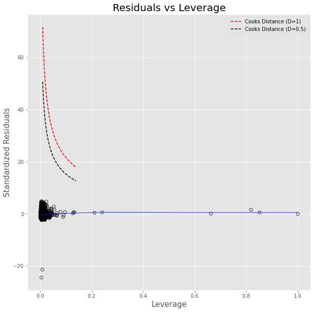

```python
#Residuals vs Leverage

from numpy import sqrt

def one_line(x):
    return sqrt((1 * len(model.params) * (1 - x)) / x)

def point_five_line(x):
    return sqrt((0.5 * len(model.params) * (1 - x)) / x)



def show_cooks_distance_lines(tx,inc,color,label):
    plt.plot(inc,tx(inc), label=label,color=color, ls='--')



sns.regplot(model.get_influence().hat_matrix_diag,
           model.get_influence().resid_studentized_internal,
            scatter=True,
            ci=False,
            lowess=True,
            line_kws={'color': 'blue', 'lw': 1, 'alpha': 0.8},
          scatter_kws={'facecolors':'none', 'edgecolors':'black'})

show_cooks_distance_lines(one_line,
                        np.linspace(.01,.14,100),
                          'red',
                          'Cooks Distance (D=1)' )

show_cooks_distance_lines(point_five_line,
                          np.linspace(.01,.14,100),
                          'black',
                          'Cooks Distance (D=0.5)')

plt.title('Residuals vs Leverage', fontsize=20)
plt.xlabel('Leverage', fontsize=15)
plt.ylabel('Standardized Residuals', fontsize=15)
plt.legend()
```

Leverage refers to the extent to which the coefficients in the regression model would change if a particular observation was removed from the datas, Standardized residuals refer to the standardized difference between a predicted value for an observation and the actual value of the observation.

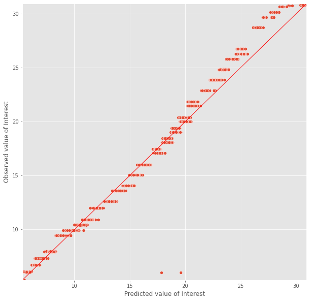

```python
Y_max = Y.max()
Y_min = Y.min()

ax = sns.scatterplot(model.fittedvalues, Y)
ax.set(ylim=(Y_min, Y_max))
ax.set(xlim=(Y_min, Y_max))
ax.set_xlabel("Predicted value of Interest")
ax.set_ylabel("Observed value of Interest")

X_ref = Y_ref = np.linspace(Y_min, Y_max, 100)
plt.plot(X_ref, Y_ref, color='red', linewidth=1)
plt.show()
```

# Random Forest

```python
def evaluate(model,X_train,X_test,Y_train,Y_test):

    model.fit(X_train,Y_train)
    predictions_train = model.predict(X_train)
    predictions_test = model.predict(X_test)

    errors_train = abs(predictions_train - Y_train)
    errors_test = abs(predictions_test - Y_test)

    mape_train = 100 * np.mean(errors_train / Y_train)
    mape_test = 100 * np.mean(errors_test / Y_test)

    accuracy_train = 100 - mape_train
    accuracy_test = 100 - mape_test
    print('Model Performance')
    print('Average Error(Train Data): {:0.4f} of int rate.'.format(np.mean(errors_train)))
    print('Average Error(Test Data): {:0.4f} of int rate.'.format(np.mean(errors_test)))

    print('Accuracy(Train Data) = {:0.2f}%.'.format(accuracy_train))
    print('Accuracy(Test Data) = {:0.2f}%.'.format(accuracy_test))

    print('Mape(Train Data): {:0.4f} of int rate'.format(mape_train))
    print('Mape(Test Data): {:0.4f} of int rate'.format(mape_test))

    plt.figure(figsize = (10,10))
    plt.scatter(predictions_train,(predictions_train - Y_train),c='g',s=40,alpha=0.5)
    plt.scatter(predictions_test,(predictions_test - Y_test),c='b',s=40,alpha=0.5)
    plt.hlines(y=0,xmin=0,xmax=30)
    plt.title('residual plot blue(test) and green(train)data')
    plt.ylabel('residuals')
    return accuracy_train,accuracy_test
```

```
Model Performance
Average Error(Train Data): 0.0072 of int rate.
Average Error(Test Data): 0.0140 of int rate.
Accuracy(Train Data) = 99.94%.
Accuracy(Test Data) = 99.92%.
Mape(Train Data): 0.0639 of int rate
Mape(Test Data): 0.0776 of int rate
```

```
(99.93607347129725, 99.92239377340046)
```

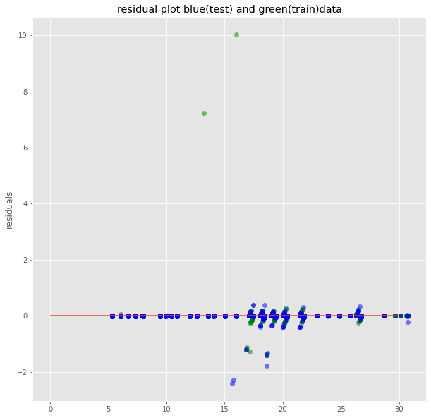

```python
# Import the model we are using
from sklearn.ensemble import RandomForestRegressor

# Instantiate model (Using Default 10 Estimators)
rf = RandomForestRegressor(n_estimators= 10, random_state=42)

# Using Evaluation Function on our First Model

evaluate(rf, X_train, X_test, Y_train, Y_test)
```

```python
# Get numerical feature importances
importances = list(rf.feature_importances_)

# List of tuples with variable and importance
feature_importances = [(feature, round(importance, 2)) for feature, importance in zip(list(X.columns), importances)]

# Sort the feature importances by most important first
feature_importances = sorted(feature_importances, key = lambda x: x[1], reverse = True)

# Print out the feature and importances
[print('Variable: {:20} Importance: {}'.format(*pair)) for pair in feature_importances];
```

```
Variable: sub_grade            Importance: 0.88
Variable: grade                Importance: 0.12
Variable: emp_title            Importance: 0.0
Variable: state                Importance: 0.0
Variable: homeownership        Importance: 0.0
Variable: verified_income      Importance: 0.0
Variable: loan_purpose         Importance: 0.0
Variable: application_type     Importance: 0.0
Variable: issue_month          Importance: 0.0
Variable: loan_status          Importance: 0.0
Variable: initial_listing_status Importance: 0.0
Variable: disbursement_method  Importance: 0.0
Variable: emp_length           Importance: 0.0
Variable: issue_month          Importance: 0.0
Variable: delinq_2y            Importance: 0.0
Variable: current_accounts_delinq Importance: 0.0
Variable: num_accounts_120d_past_due Importance: 0.0
Variable: annual_income        Importance: 0.0
Variable: debt_to_income       Importance: 0.0
Variable: months_since_last_delinq Importance: 0.0
Variable: earliest_credit_line Importance: 0.0
Variable: inquiries_last_12m   Importance: 0.0
Variable: total_credit_lines   Importance: 0.0
Variable: open_credit_lines    Importance: 0.0
Variable: total_credit_limit   Importance: 0.0
Variable: total_credit_utilized Importance: 0.0
Variable: num_collections_last_12m Importance: 0.0
Variable: num_historical_failed_to_pay Importance: 0.0
Variable: total_collection_amount_ever Importance: 0.0
Variable: current_installment_accounts Importance: 0.0
Variable: accounts_opened_24m  Importance: 0.0
Variable: months_since_last_credit_inquiry Importance: 0.0
Variable: num_satisfactory_accounts Importance: 0.0
Variable: num_accounts_30d_past_due Importance: 0.0
Variable: num_active_debit_accounts Importance: 0.0
Variable: total_debit_limit    Importance: 0.0
Variable: num_total_cc_accounts Importance: 0.0
Variable: num_open_cc_accounts Importance: 0.0
Variable: num_cc_carrying_balance Importance: 0.0
Variable: num_mort_accounts    Importance: 0.0
Variable: account_never_delinq_percent Importance: 0.0
Variable: tax_liens            Importance: 0.0
Variable: public_record_bankrupt Importance: 0.0
Variable: loan_amount          Importance: 0.0
Variable: term                 Importance: 0.0
Variable: installment          Importance: 0.0
Variable: balance              Importance: 0.0
Variable: paid_total           Importance: 0.0
Variable: paid_principal       Importance: 0.0
Variable: paid_interest        Importance: 0.0
Variable: paid_late_fees       Importance: 0.0
```

```python
x_new = X[['grade','sub_grade']]
```

```
Model Performance
Average Error(Train Data): 0.0355 of int rate.
Average Error(Test Data): 0.0330 of int rate.
Accuracy(Train Data) = 99.76%.
Accuracy(Test Data) = 99.81%.
Mape(Train Data): 0.2415 of int rate
Mape(Test Data): 0.1902 of int rate
```

```
(99.75850030669258, 99.8097959476314)
```

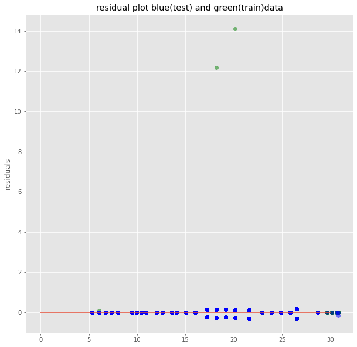

```python
# New random forest with only the most important variables (Default 10 Estimators)

rf_most_important = RandomForestRegressor(n_estimators= 10, random_state=42)

X_train_new = X_train[['grade','sub_grade']]
X_test_new = X_test[['grade','sub_grade']]

evaluate(rf_most_important,X_train_new,X_test_new,Y_train,Y_test)
```

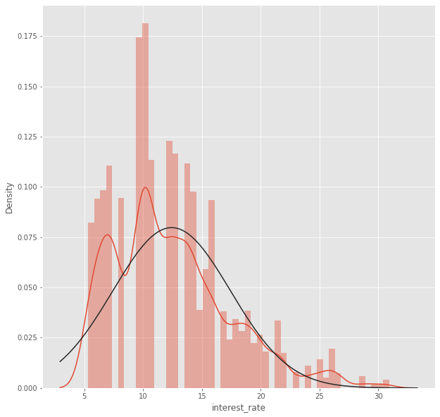

```python
    from scipy.stats import norm
    sns.distplot(loan_df['interest_rate'], fit=norm)
    plt.show()
```

```python
from sklearn.model_selection import train_test_split
from sklearn.ensemble import RandomForestRegressor
from sklearn.metrics import accuracy_score, confusion_matrix, classification_report
```

```python
# Instantiate and fit the RandomForestClassifier
forest = RandomForestRegressor(n_estimators= 10, random_state=42)
forest.fit(X_train, Y_train)
```

```
RandomForestRegressor(n_estimators=10, random_state=42)
```

```python
y_pred_test = forest.predict(X_test)
```

```python
print(y_pred_test)
```

```
[ 6.72  14.08  25.81  ...  6.072  6.716  7.969]
```

### If I had more time, I would perform hyperparameter tuning using gridsearch and k-fold crossvalidation and improve the model.

### Furthermore, I would also test the interest rate predictions with several other models like XGBoost and KNN regression.